# Demographics Analysis

## Demographic Data Set Analysis

To assess how different demographic groups are impacted by diabetes, we will conduct survival analysis using diabetes diagnosis as the event and the age of diagnosis as the time to event. There are several demographic variables that the data set provides information on that we can analyze. To start, we looked at the two binary categorical variables provided: birth country and gender. We used the R survival package to plot Kaplan-Meier curves stratified by each variable to compare the development of diabetes in each group.

#### Survival Curve Stratified by Birth Country

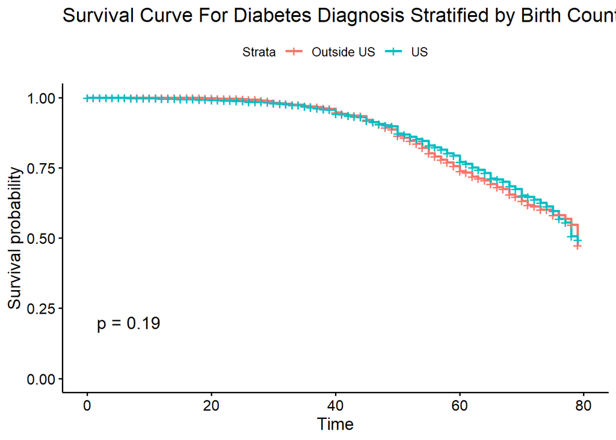

The time to diabetes diagnosis does not appear to be significantly different in those born outside of the United States compared to those born in the United States at the p = 0.05 level.

#### Survival Curve Stratified by Gender

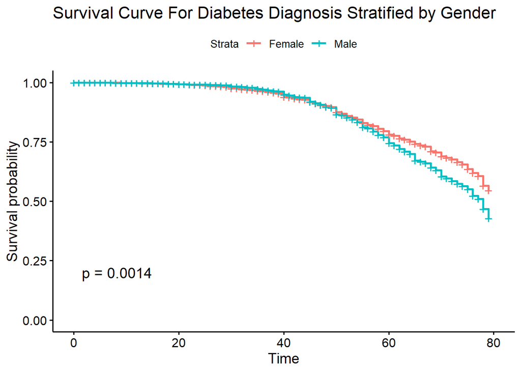

The time to diabetes diagnosis also appears to be significantly different in males and females at the p = 0.05 level with females having a higher survival probability.

Next we looked at the categorical variables with several levels: race and education level. The race variable has values “Mexican American”, “Non Hispanic Asian”, “Non Hispanic Black”, “Non Hispanic White”, “Other Hispanic”, and “Other Race”. The education level variable has values “Less Than High School”, “Some High School”, “High School Graduate”, “Associates Degree/Some College”, “College Graduate”, and “Unknown”.

#### Survival Curve Stratified by Race

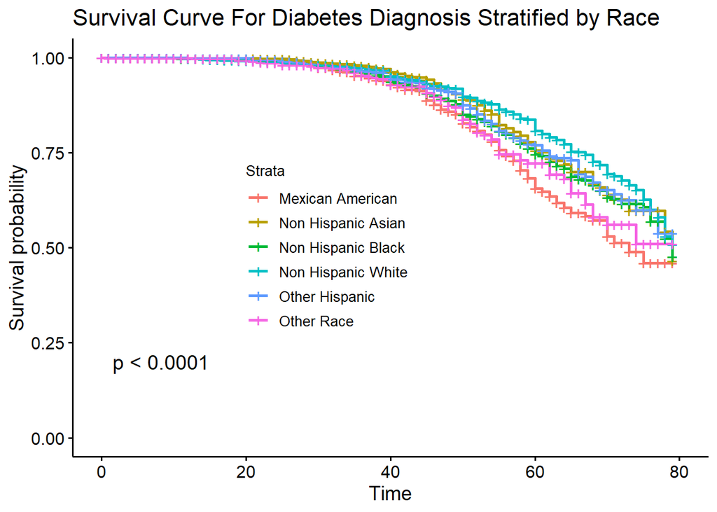

Time to diabetes diagnosis is significantly different across different races at the p = 0.0001 significance level. The survival probability seems to be higher for the non-hispanic white group than any other race.

#### Survival Curve Stratified by Education Level

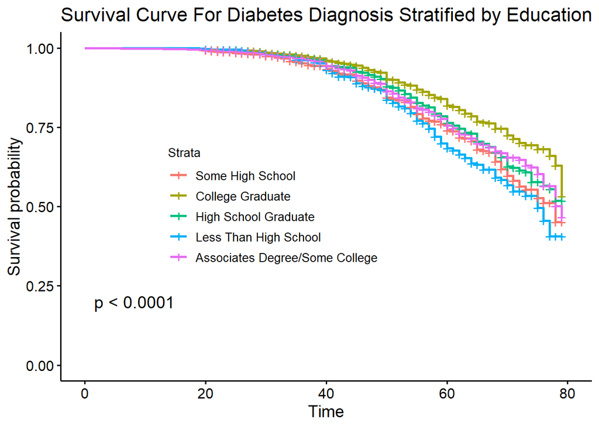

Time to diabetes diagnosis is significantly different for different education levels at the p=0.05 level. Individuals who have graduated college have the highest survival probability and individuals with less than a high school education have the lowest survival probability.

Finally, we looked at the continuous variables provided in the demographic data. The two continuous variables are age and family income. Because we are looking at survival curves, we would be unable to gain meaningful insights from comparing different age groups so we did not include the age variable in this analysis.

#### Survival Curve Stratified by Family Income

The family income variable provides the ratio of each families income to the national poverty line. To compare survival time based on family income as a continuous variable we have to convert it to a categorical variable. To accomplish this we split the data into five equally sized bins and compared the quintiles in the analysis.

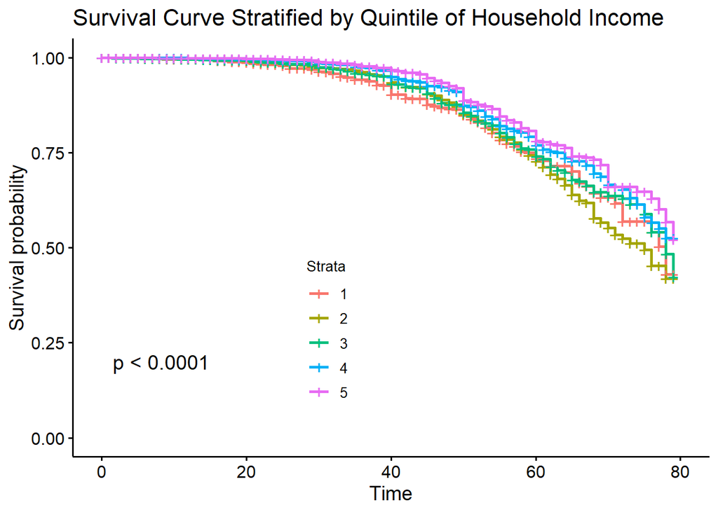

From the Kaplan-Meier curves we see that there is a significant difference in the time to diabetes diagnosis based on household income. The highest income quintile has the highest survival probability.